# Analysis of the ToothGrowth data

Vrinda Prabhu

Sunday 31 January 2016

In this project we use the inherent ToothGrowth dataset to perform some basic exploratory data analyses.Also we draw some conclusions based on confidence intervals and/or hypothesis tests to compare tooth growth by supp and dose.

Loading the required library

```r
library(ggplot2)
library(plyr)
library(gridExtra)
library(datasets)
```

Loading the required data and having a first look at it

```r
data(ToothGrowth)
str(ToothGrowth)
```

```
## 'data.frame':    60 obs. of  3 variables:
##  $ len : num  4.2 11.5 7.3 5.8 6.4 10 11.2 11.2 5.2 7 ...
##  $ supp: Factor w/ 2 levels "OJ","VC": 2 2 2 2 2 2 2 2 2 2 ...
##  $ dose: num  0.5 0.5 0.5 0.5 0.5 0.5 0.5 0.5 0.5 0.5 ...
```

```r
ToothGrowth <- ToothGrowth
ToothGrowth$dose = as.factor(ToothGrowth$dose)

head(ToothGrowth)
```

```
##    len supp dose
## 1  4.2   VC  0.5
## 2 11.5   VC  0.5
## 3  7.3   VC  0.5
## 4  5.8   VC  0.5
## 5  6.4   VC  0.5
## 6 10.0   VC  0.5
```

## Exploratory Analysis

```r
explore_plot <- ggplot(ToothGrowth,aes(x = dose,y = len))
explore_plot <- explore_plot  + geom_point(data = ToothGrowth,aes(colour=supp),size=4) +
                          xlab('Dosage') + ylab('Length') +
                          labs(title = 'Effect of supp on tooth growth for particular dosage') +
                          theme(plot.title = element_text(face ='bold',hjust = 0.5))
```

Not much detailed insights can be observed except that both orange juice and vitamin C have greater impact on higher dosages.

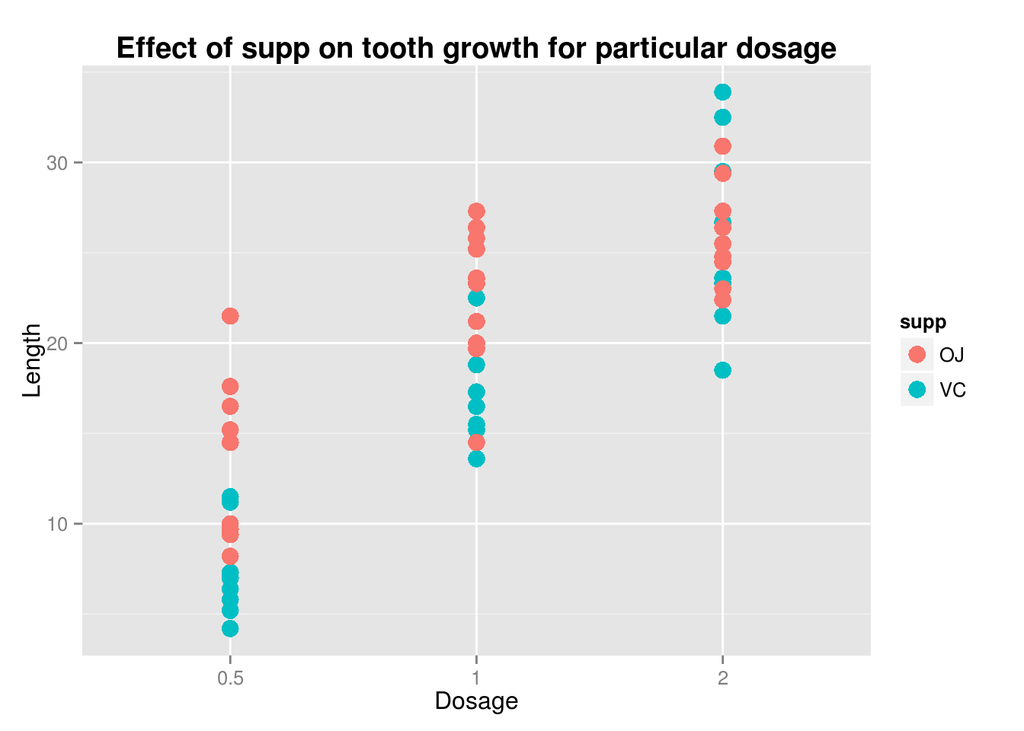

Let us do box plots for a more precise understanding.

```r
separate_supp_plot <- ggplot(data=ToothGrowth, aes(x=dose,y=len,fill=dose))
separate_supp_plot <- separate_supp_plot + geom_boxplot() + facet_grid(.~supp) +
                                            xlab('Dosage') + ylab('Length') +
                                            labs(title = 'Effect of tooth growth across supp') +
                                            theme(plot.title = element_text(face ='bold',hjust = 0.5))


separate_dose_plot <- ggplot(data=ToothGrowth, aes(x=supp,y=len,fill=supp))
separate_dose_plot <- separate_dose_plot + geom_boxplot() + facet_grid(.~dose) +
                                            xlab('Supp') + ylab('Length') +
                                            labs(title = 'Effect of tooth growth across dosages') +
                                            theme(plot.title = element_text(face ='bold',hjust = 0.5))
```

The below plot allows us to draw some interesting insights: The medians across the 0.5 and 1 dosages varies.This means that VC and OJ have completely variable impact on length.

- At 0.5 dosage,VC shows right skewness (Even OJ but on a smaller scale).OJ has a greter impact on length.
- At 1 dosage both VC and OJ have an even spread around the median in the IQR.Even here OJ has a larger impact also the IQR is greater for OJ meaning higher variablity across lengths.
- At 2 dosage,both have equal medians.This means on an average both have same impact on length.But a greater spread of VC confirms that the variablity is higher than OJ.

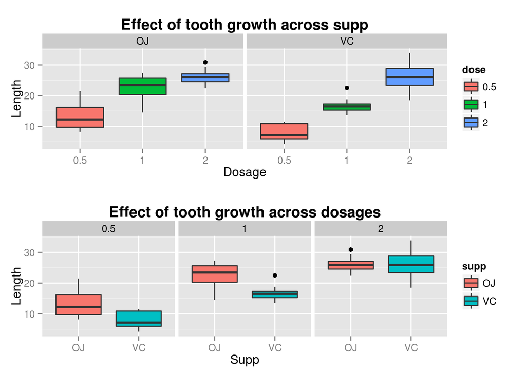

This can be re-iterated using summary statistics.

For OJ :

```
##       len        supp     dose
##  Min.   : 8.20   OJ:30   0.5:10
##  1st Qu.:15.53   VC: 0   1  :10
##  Median :22.70           2  :10
##  Mean   :20.66
##  3rd Qu.:25.73
##  Max.   :30.90
```

For VC :

```
##       len        supp     dose
##  Min.   : 4.20   OJ: 0   0.5:10
##  1st Qu.:11.20   VC:30   1  :10
##  Median :16.50           2  :10
##  Mean   :16.96
##  3rd Qu.:23.10
##  Max.   :33.90
```

We can even have a look at the variabilty across dosages for each supplement to get a clearer understading.

```r
ddply(ToothGrowth, .(supp,dose), summarise, variance=var(len))
```

```
##   supp dose  variance
## 1   OJ  0.5 19.889000
## 2   OJ    1 15.295556
## 3   OJ    2  7.049333
## 4   VC  0.5  7.544000
## 5   VC    1  6.326778
## 6   VC    2 23.018222
```

## Deriving conclusions using Hypothesis Testing

### Assumptions

Since we will primarily use t-tests,we have to make following assumptions :  
1. Tooth growth (len) follows a normal distribution.  
2. Variances of tooth growth are different when using different supplement and dosage.  
3. The variables (len, dose, supp) must be independent and identically distributed (i.i.d.).

### Hypothesis 1:

Null : The variation of length is independent of dosages.  
Alternate : Greater the dosage,greater is increase in the length.

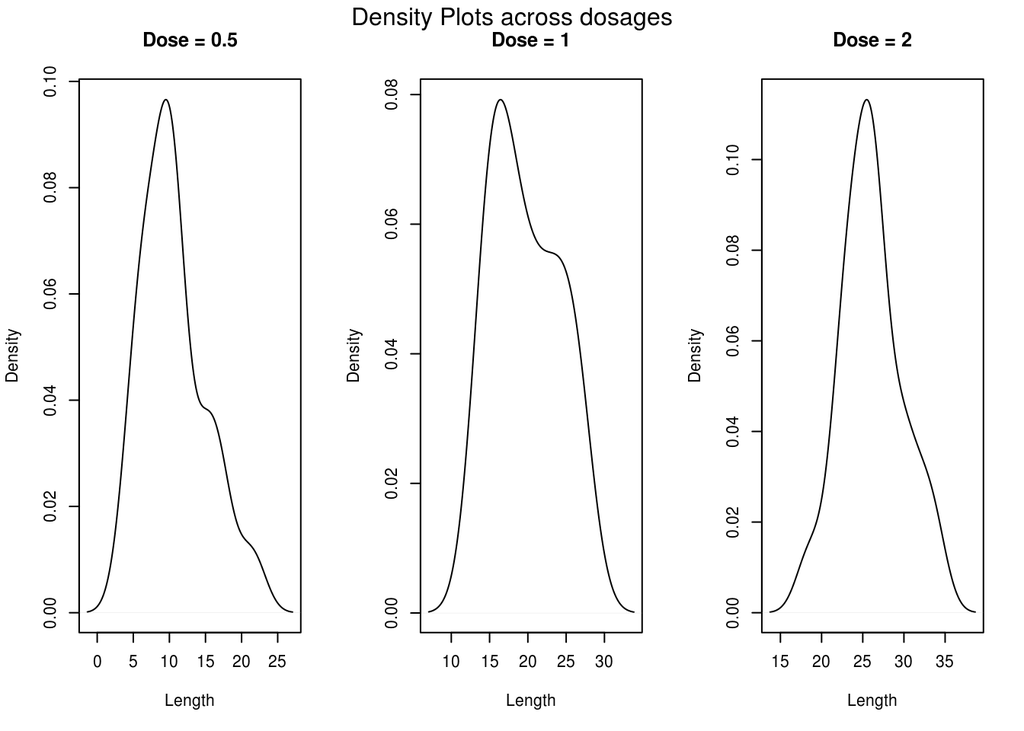

```r
dosage_group <- split(x = ToothGrowth,f = ToothGrowth$dose , drop = FALSE)

par(mfrow=c(1,3))
plot(density(dosage_group[[1]]$len),xlab = 'Length',main = 'Dose = 0.5')
plot(density(dosage_group[[2]]$len),xlab = 'Length',main = 'Dose = 1')
plot(density(dosage_group[[3]]$len),xlab = 'Length',main = 'Dose = 2')
mtext("Density Plots across dosages", side=3, outer=TRUE, line=-1.5)
```

Since the length across dosages are roughly normally distributed,we can proceed with t-Test to compare the means of two groups.

```r
dose_05_1 <- t.test(dosage_group[[1]]['len'], dosage_group[[2]]['len'], alternative = "less", paired = FALSE, var.equal = FALSE, conf.level = 0.95)
dose_05_1
```

```
##
##  Welch Two Sample t-test
##
## data:  dosage_group[[1]]["len"] and dosage_group[[2]]["len"]
## t = -6.4766, df = 37.986, p-value = 6.342e-08
## alternative hypothesis: true difference in means is less than 0
## 95 percent confidence interval:
##       -Inf -6.753323
## sample estimates:
## mean of x mean of y
##    10.605    19.735
```

```r
dose_1_2 <- t.test(dosage_group[[2]]['len'],dosage_group[[3]]['len'], alternative = "less", paired = FALSE, var.equal = FALSE, conf.level = 0.95)
dose_1_2
```

```
##
##  Welch Two Sample t-test
##
## data:  dosage_group[[2]]["len"] and dosage_group[[3]]["len"]
## t = -4.9005, df = 37.101, p-value = 9.532e-06
## alternative hypothesis: true difference in means is less than 0
## 95 percent confidence interval:
##      -Inf -4.17387
## sample estimates:
## mean of x mean of y
##    19.735    26.100
```

```r
cat('p-values across both the tests are ',dose_05_1$p.value,'and',dose_1_2$p.value,'respectively')
```

```
## p-values across both the tests are  6.341504e-08 and 9.532148e-06 respectively
```

#### Conclusion

Since p-values in both the cases are less than 0.05, *we can reject the null hypothesis*. It can be safely concluded that higher the dosage, the greater the impact on tooth growth.

### Hypothesis 2:

Null : The variation of length is independent of supplement.  
Alternate : More tooth growth when using supplement OJ than VC.

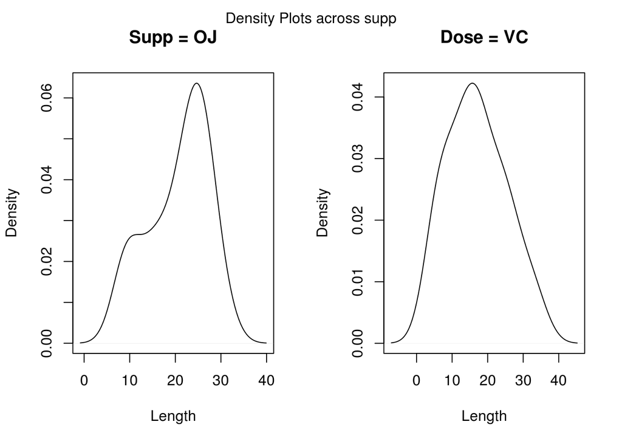

```r
supp_group <- split(x = ToothGrowth,f = ToothGrowth$supp , drop = FALSE)

par(mfrow=c(1,2))
plot(density(supp_group[[1]]$len),xlab = 'Length',main = 'Supp = OJ')
plot(density(supp_group[[2]]$len),xlab = 'Length',main = 'Dose = VC')
mtext("Density Plots across supp", side=3, outer=TRUE, line=-1.5)
```

Since the length across supplements are roughly normally distributed,we can proceed with t-Test to compare the means of two groups.Also we can see that plot center of OJ is greater than VC.

```r
supp_OJ_VC <- t.test(supp_group[[1]]['len'],supp_group[[2]]['len'], alternative = "greater", paired = FALSE, var.equal = FALSE, conf.level =0.95)
supp_OJ_VC
```

```
##
##  Welch Two Sample t-test
##
## data:  supp_group[[1]]["len"] and supp_group[[2]]["len"]
## t = 1.9153, df = 55.309, p-value = 0.03032
## alternative hypothesis: true difference in means is greater than 0
## 95 percent confidence interval:
##  0.4682687       Inf
## sample estimates:
## mean of x mean of y
##  20.66333  16.96333
```

```r
cat('p-values in of the test is',supp_OJ_VC$p.value)
```

```
## p-values in of the test is 0.03031725
```

#### Conclusion

Since p-values is less than 0.05, we can reject the null hypothesis. It can be concluded that if supplement is OJ, it has a greater impact on tooth growth than VC.

**However because of the conclusion of box-plot (recall same median at dose = 2),let us try to be little more detailed on above conclusion.**

Splitting data on supp and dose levels and including a t-test function.

```r
supp_dose_group <- split(x = ToothGrowth,f = list(ToothGrowth$supp,ToothGrowth$dose) , drop = FALSE)

p_val_list <- NULL
for(i in seq(from = 1,length(supp_dose_group),by=2)){
  p_val <- t.test(supp_dose_group[[i]]['len'],supp_dose_group[[i+1]]['len'],paired = FALSE, var.equal = FALSE, conf.level =0.95)
  p_val_list <- c(p_val_list,p_val$p.value)
}

cat('p-value for dose = 0.5 is',p_val_list[[1]])
```

```
## p-value for dose = 0.5 is 0.006358607
```

```r
cat('p-value for dose = 1 is',p_val_list[[2]])
```

```
## p-value for dose = 1 is 0.001038376
```

```r
cat('p-value for dose = 2 is',p_val_list[[3]])
```

```
## p-value for dose = 2 is 0.9638516
```

## Overall Conclusion

So in detail :  
1. There is an impact on tooth growth by dosage.Higher the dosage higher the tooth growth length (either OJ or VC).  
2. We can safely reject the null hypothesis that in dose = 0.5 and dose = 1, and accept that OJ supplement has a greater impact on tooth growth than VC (p-value < 0.05).  
3. However,when dose = 2,we cannot claim the same since p-value > 0.05,hence ,**we cannot reject the null hypothesis** but conclude that **there is insufficient evidence** to show that OJ has higher impact than VC.